# Create reference directory for mapping

`scrattch.mapping` offers functions to convert completed single cell/nucleus RNA-seq analysis (e.g., a counts matrix + cell type assignments) into a standard reference taxonomy compatible with various mapping techniques, as well as functions to perform such mapping analyses. Several functions are also provided for conversion of output results into data and folder formats compatabile with Allen Institute R shiny tools.

The `scrattch.mapping` package is one component of the scrattch suite of packages for `S`ingle `C`ell `R`NA-seq `A`nalysis for `T`ranscriptomic `T`ype `CH`aracterization from the Allen Institute.

For this vignette, we use the dataset published in [Tasic, et al. (2016) Nature Neuroscience](https://www.ncbi.nlm.nih.gov/pmc/articles/PMC4985242/), which is available in the [tasic2016data package](https://github.com/AllenInstitute/tasic2016data):

```r
if(!"tasic2016data" %in% rownames(installed.packages())) {
  devtools::install_github("AllenInstitute/tasic2016data")
}
suppressPackageStartupMessages({
  library(tasic2016data)
})
```

This vignette also creates taxonomy standards published in [Miller, et al. (2020) eLife](https://elifesciences.org/articles/59928) using the [CCN R package](https://github.com/AllenInstitute/CCN).

```r
if(!"CCN" %in% rownames(installed.packages())) {
  ## Imported packages
  packages <- c("remotes","jsonlite","data.table","ggplot2","dendextend","dplyr","BiocManager")
  packages <- packages[!(packages %in% installed.packages()[,"Package"])]
  if(length(packages)>0) install.packages(new.packages, repos='http://cran.us.r-project.org')
  BiocManager::install("rols", update=FALSE)

  ## CCN install
  remotes::install_github("AllenInstitute/CCN", build_vignettes = TRUE)
}
suppressPackageStartupMessages({
  library(CCN)
})
```

### Workspace set-up

First, let’s create a directory in the current working directory to store the reference taxonomy files.

```r
refFolder <- paste0(getwd(),"/reference/")
dir.create(refFolder, showWarnings = FALSE)
print(refFolder)
```

```
## [1] "Z:/humancelltypes/JeremyM/github/scrattch-mapping/scrattch-mapping/vignettes/reference/"
```

Load libraries and set options.

```r
suppressPackageStartupMessages({
  library("scrattch.mapping")
})
options(stringsAsFactors = FALSE)
options(future.globals.maxSize = 4000 * 1024^2)  # Can adjust this value if needed, depending on number of cells
options(future.rng.onMisuse="ignore")
```

Read in the reference data (in this case we will use the Tasic 2016 data, which includes ~1800 cells from mouse primary visual cortex), and exclude unclustered cells.

```r
annotations <- tasic_2016_anno
counts      <- tasic_2016_counts  # uncomment if using CPM below
annotations <- annotations[match(colnames(counts),annotations$sample_name),]  # Put them in the correct order
rownames(annotations) <- annotations$sample_name

kp          <- annotations$broad_type!="Unclassified"
counts      <- counts[,kp]
annotations <- annotations[kp,]
```

Now we are going to rename some of the annotations to match current Allen Institute terminology. This is not strictly necessary, but is useful.

```r
# Rename the primary cell type to "cluster"
clusters            <- annotations$primary_type_label[match(1:49,annotations$primary_type_id)]
annotations$cluster <- factor(annotations$primary_type_label, levels=clusters)

# Retain cluster colors
cluster_colors <- setNames(annotations$primary_type_color[match(1:49,annotations$primary_type_id)], clusters)

# Create a class label that groups all non-neurons together
annotations$class <- annotations$broad_type
annotations$class[!is.element(annotations$class,c("GABA-ergic Neuron","Glutamatergic Neuron"))] = "Non-neuronal"

# Create a subclass label (e.g., intermediate resolution between class and cell type)
subclass <- c(rep("CGE",9),rep("MGE",13),"CGE",rep("Exc IT",10),rep("Exc non-IT",9),rep("NN",7))
subclass <- setNames(subclass,annotations$cluster[match(1:49,annotations$cluster_id)])
subclass <- subclass[annotations$cluster]
subclass[annotations$class=="Non-neuronal"] <- annotations$broad_type[annotations$class=="Non-neuronal"]
annotations$subclass <- gsub("Oligodendrocyte Precursor Cell","OPC",subclass)
head(data.frame(annotations[,c("cluster","subclass","class")]))
```

```
##                             cluster subclass                class
## Calb2_tdTpositive_cell_1 Vip Mybpc1      CGE    GABA-ergic Neuron
## Calb2_tdTpositive_cell_2  Vip Parm1      CGE    GABA-ergic Neuron
## Calb2_tdTpositive_cell_3   L4 Ctxn3   Exc IT Glutamatergic Neuron
## Calb2_tdTpositive_cell_4   Vip Chat      CGE    GABA-ergic Neuron
## Calb2_tdTpositive_cell_5  Vip Parm1      CGE    GABA-ergic Neuron
## Calb2_tdTpositive_cell_6 L2/3 Ptgs2   Exc IT Glutamatergic Neuron
```

Finally, prior to generating the taxonomy, we need to define a set of variable genes and build a 2-dimensional representation of the data. To do this we use binary genes and the `umap` R library, respectively, although other options could also be used (for example, the Seurat R package often provides comparable or better looking results).

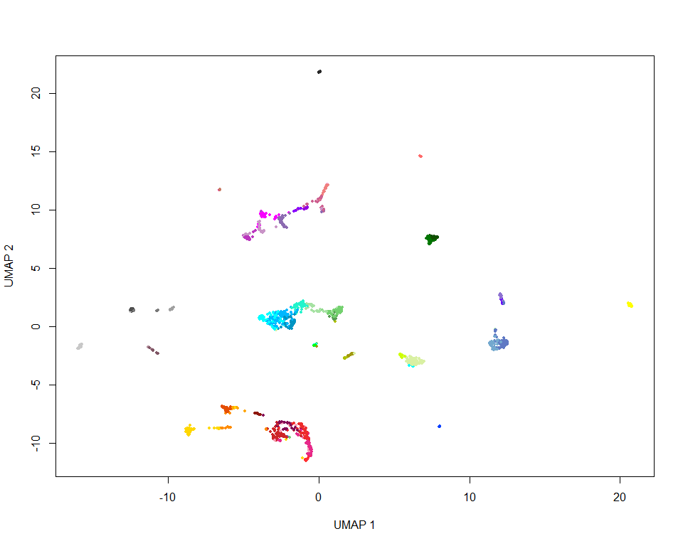

```r
## Get top 1000 genes by a beta (binary) score
binary.genes <- top_binary_genes(counts,annotations$cluster,1000)

## Calculate a UMAP based on these binary genes.
npcs <- 30
pcs  <- prcomp(logCPM(counts)[binary.genes,], scale = TRUE)$rotation
umap.coords <- umap(pcs[,1:npcs])$layout

## View the output as a sanity check
plot(umap.coords[,1],umap.coords[,2],col=annotations$primary_type_color, pch=19, cex=0.5,
     main="",xlab="UMAP 1", ylab="UMAP 2")
```

## Generate the reference directory

Next, create the reference folder with all associated files, and a preliminary dendrogram. The dendrogram will get updated in later functions.

```r
buildReference(counts         = counts,
               meta.data      = annotations,
               feature.set    = binary.genes,
               umap.coords    = umap.coords,
               shinyFolder    = refFolder,
               cluster_colors = cluster_colors,  # Colors are generated if not provided
               metadata_names = NULL,     # If you want to save only selected metadata columns
               subsample      = 100,      # This is the number of cells per cluster
               reorder.dendrogram = TRUE) # This will match the factor order of the clusters to the extent possible
```

```
## [1] "===== Building counts.feather ====="
## [1] "===== Building data_t.feather ====="
## [1] "===== Building data.feather ====="
## [1] "===== Format metadata table for R shiny folder ====="
## [1] "===== Building dendrogram ====="
```

```
## [1] "===== Building umap/tsne feathers (precalculated) ====="
## [1] "===== Building count, median, sum feathers ====="
```

Now we annotate the dendrogram with marker genes. This is only required for using tree mapping, and is critical if this reference is to be used for processing Patch-seq data from the Allen Institute. For other mapping strategies, this is not needed. Note that we can either pull data and metadata from variables or directly from the reference folder. This example pulls from the reference folder.

```r
dend <- addDendrogramMarkers(dend     = readRDS(paste0(refFolder,"dend.RData")),
                             norm.data= paste0(refFolder,"data_t.feather"),
                             metadata = paste0(refFolder,"anno.feather"),
                             shinyFolder = refFolder,
                             subsample= 25) # To speed up calculations a bit
```

```
## [1] "Define some relevant variables"
## [1] "Define marker genes and gene scores for the tree"
## [1] "=== NOTE: This step can be very slow (several minute to many hours)."
## [1] "      To speed up the calculation (or if it crashes) try decreasing the value of subsample."
## [1] "Calculate gene scores"
## [1] "Build the reference dendrogram"
## [1] "Save the reference dendrogram"
## [1] "Build membership table of reference vs. reference for use with patch-seq mapping"
```

Now define this as a standardized taxonomy and output the relevant zip file (see CCN library for more information).

```r
## Create taxonomy and nomenclature standards for this taxonomy
taxonomy_id       <- "CCN202301170"          # Taxonomy ID of format CCN<YYYYMMDD><T>
taxonomy_author   <- "Bosiljka Tasic"        # Person uploading the data and taxonomy
taxonomy_citation <- "10.1038/nn.4216"       # DOI of relevant taxonomy citation, if any
first_label       <- setNames("RNA", 1)      # Prefix for cell set label (adjust text label only)
structure         <- "primary visual cortex" # Brain structure.  Ontology tag is auto-generated.

# Some metadata variables (probably this doesn't need to be edited)
metadata         <- as.data.frame(read_feather(paste0(refFolder,"anno.feather")))
metadata_columns <- c("subclass_label", "class_label")
metadata_order   <- c("subclass_order", "class_order")
cluster_column   <- "cluster_label"

# Named vector of cell to cell type assignments (can be auto-generated, but better to include)
cell_assignment  <- setNames(metadata$cluster_label,metadata$sample_name)

# This line of code will run all the scripts, output the relevant zip file to nomenclature.zip in your working directory, and return the same variables for further manipulation in R.
ccn_output <- apply_CCN(dend = dend,
                        cell_assignment   = cell_assignment,
                        metadata          = metadata,
                        first_label       = first_label,
                        taxonomy_id       = taxonomy_id,
                        taxonomy_author   = taxonomy_author,
                        taxonomy_citation = taxonomy_citation,
                        structure         = structure,
                        metadata_columns  = metadata_columns,
                        metadata_order    = metadata_order,
                        cluster_column    = cluster_column,
                        ccn_filename      = paste0(refFolder,"nomenclature.zip"))
```

```
## [1] "Updating table for subclass_label"
## [1] "Updating table for class_label"
```

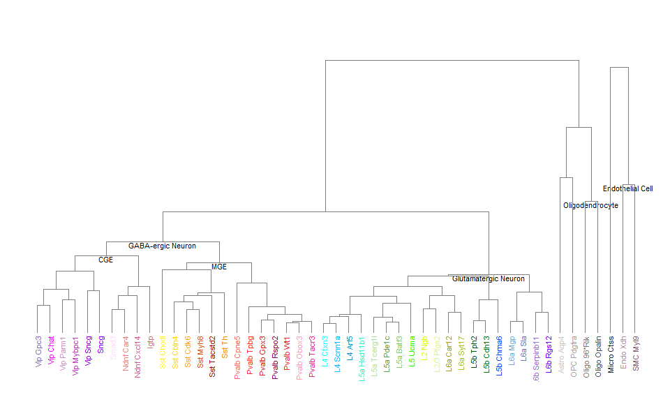

```r
# Plot the dendrogram (note that this function sometimes does not display the root node correctly)
plot_dend(ccn_output$final_dendrogram,node_size = 3)
```

```r
# Overwrite the existing dendrogram with the annotated version
dend <- ccn_output$final_dendrogram
saveRDS(dend, file.path(refFolder,"dend.RData"))
```

```r
writePatchseqQCmarkers(counts = paste0(refFolder,"counts.feather"),  # can also read matrix directly
                       metadata = paste0(refFolder,"anno.feather"),  # can also read matrix directly
                       subsample = 100,  # Default of 100 is reasonable
                       subclass.column = "subclass_label",  # default
                       class.column = "class_label",  # default
                       off.target.types = "Non-neuronal",  # default is various iterations of non-neuronal
                       num.markers = 50,     # Default of 50 is probably fine
                       shinyFolder = refFolder)
```

```
## [1] "Define and output marker genes for each broad class and off-target subclass."
## [1] "Complete!"
```

Finally, we read package this information to a compact annData format compatible with both R and python. **This annData object is the input file for all mapping algorithms in this package, and a to-be-created parallel python package.**.

```r
AIT.anndata <- loadTaxonomy(refFolder, hGenes=binary.genes)
```

```
## [1] "Loading reference taxonomy into memory."
## [1] "Done loading reference"
## [1] "Done loading UMAP"
```

```r
write_h5ad(AIT.anndata,"reference.h5ad")
```